# Henry Fernandez - Loan Prediction

#### months_since_borrower_last_delinquency

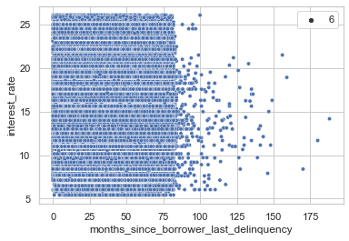

```python
sns.set(style = 'whitegrid')
ax = sns.scatterplot(x = data['months_since_borrower_last_delinquency'], y=data['interest_rate'], size = 6)
```

Maybe something < or > 75 for a feature?

#### months_since_last_public_record

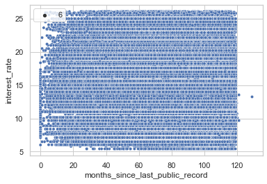

```python
sns.set(style = 'whitegrid')
ax = sns.scatterplot(x = data['months_since_last_public_record'], y=data['interest_rate'], size = 6)
```

#### Num borrower open credit lines

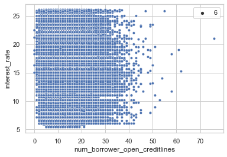

```python
sns.set(style = 'whitegrid')
ax = sns.scatterplot(x = data['num_borrower_open_creditlines'], y=data['interest_rate'], size = 6)
```

#### num_derogatory_public_records

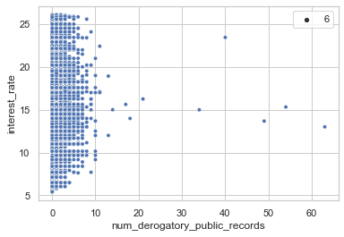

```python
sns.set(style = 'whitegrid')
ax = sns.scatterplot(x = data['num_derogatory_public_records'], y=data['interest_rate'], size = 6)
```

#### Credit Revolving Balance

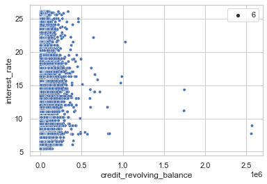

```python
sns.set(style = 'whitegrid')
ax = sns.scatterplot(x = data['credit_revolving_balance'], y=data['interest_rate'], size = 6)
```

#### Revolving Line utlization rate

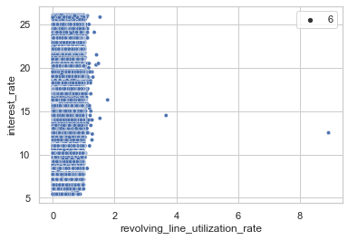

```python
sns.set(style = 'whitegrid')
ax = sns.scatterplot(x = data['revolving_line_utilization_rate'], y=data['interest_rate'], size = 6)
```

Not informative

#### loan_initial_listing_status

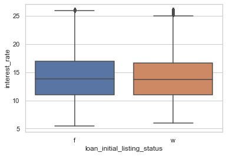

```python
sns.set(style = 'whitegrid')
ax = sns.boxplot(x = data['loan_initial_listing_status'], y= data['interest_rate'])
```

Can drop this. nothing really to be gained it seems

### Some Notes After visualizing these:

Potential Good Categorical Predictors:

- Num payments
- Loan Grade
- Loan Subgrade
- Income verified
- Loan category

### Clean Loan Requested and Invester Portion

```python
data['loan_requested'] = data['loan_requested'].replace('[\$,]','',regex=True).astype(float)
data['invester_portion'] = data['invester_portion'].replace('[\$,]','',regex=True).astype(float)
```

# Quick Check for Collinearity

```python
data = data.drop('months_since_borrower_last_delinquency', axis = 1)
```

```python
data = data.dropna()
```

```python
from statsmodels.stats.outliers_influence import variance_inflation_factor

vif_check_vars = data[['loan_requested','invester_portion','borrower_annual_income','ratio','num_pastdue','num_creditor_inquiries',
                      'months_since_last_public_record','num_borrower_open_creditlines',
                      'num_derogatory_public_records','credit_revolving_balance','revolving_line_utilization_rate',
                       'num_borrower_credit_lines']]
vif = pd.DataFrame()

vif["feature"] = vif_check_vars.columns
vif["VIF"] = [variance_inflation_factor(vif_check_vars.values, i) for i in range(len(vif_check_vars.columns))]

vif
```

|  | feature | VIF |
| --- | --- | --- |
| 0 | loan_requested | 309.480228 |
| 1 | invester_portion | 305.730741 |
| 2 | borrower_annual_income | 3.434671 |
| 3 | ratio | 7.189266 |
| 4 | num_pastdue | 1.151875 |
| 5 | num_creditor_inquiries | 1.622128 |
| 6 | months_since_last_public_record | 7.111793 |
| 7 | num_borrower_open_creditlines | 12.036892 |
| 8 | num_derogatory_public_records | 1.103989 |
| 9 | credit_revolving_balance | 2.127442 |
| 10 | revolving_line_utilization_rate | 6.455763 |
| 11 | num_borrower_credit_lines | 11.199824 |

loan_requested and investor portion are highly collinear. need to drop one.

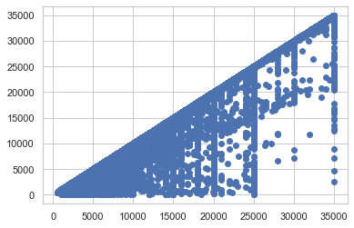

```python
plt.scatter(vif_check_vars.loan_requested, vif_check_vars.invester_portion)
```

```python
data.loan_requested.corr(data.invester_portion)

#Can't have this. extremely high correlation
```

```
0.9935467243145171
```

```python
data = data.drop('invester_portion',axis = 1)
```

Dropping investor portion.

## Select Important Features and Get Dummies

```python
data.info()
```

```
<class 'pandas.core.frame.DataFrame'>
Int64Index: 205709 entries, 7 to 399998
Data columns (total 20 columns):
 #   Column                           Non-Null Count   Dtype
---  ------                           --------------   -----
 0   interest_rate                    205709 non-null  float64
 1   loan_requested                   205709 non-null  float64
 2   num_payments                     205709 non-null  object
 3   loan_grade                       205709 non-null  object
 4   loan_subgrade                    205709 non-null  object
 5   home_ownership_status            205709 non-null  object
 6   borrower_annual_income           205709 non-null  float64
 7   income_verified                  205709 non-null  object
 8   loan_category                    205709 non-null  object
 9   ratio                            205709 non-null  float64
 10  num_pastdue                      205709 non-null  float64
 11  earliest_reported_date           205709 non-null  object
 12  num_creditor_inquiries           205709 non-null  float64
 13  months_since_last_public_record  205709 non-null  float64
 14  num_borrower_open_creditlines    205709 non-null  float64
 15  num_derogatory_public_records    205709 non-null  float64
 16  credit_revolving_balance         205709 non-null  float64
 17  revolving_line_utilization_rate  205709 non-null  float64
 18  num_borrower_credit_lines        205709 non-null  float64
 19  loan_initial_listing_status      205709 non-null  object
dtypes: float64(12), object(8)
memory usage: 33.0+ MB
```

```python
data_final = data[['interest_rate','loan_requested','borrower_annual_income','ratio',
               'loan_grade','loan_category','income_verified','num_payments','loan_subgrade']]

#num_derogatory_public_records#
```

```python
data_final.drop(data_final[data_final['loan_category'] == 'educational'].index, inplace = True)
```

```python
data_final.info()
```

[output not shown]

```python
data_final = pd.get_dummies(data_final)
```

```python
data_final.info()
```

```
<class 'pandas.core.frame.DataFrame'>
Int64Index: 205527 entries, 7 to 399998
Data columns (total 57 columns):
 #   Column                                    Non-Null Count   Dtype
---  ------                                    --------------   -----
 0   interest_rate                             205527 non-null  float64
 1   loan_requested                            205527 non-null  float64
 2   borrower_annual_income                    205527 non-null  float64
 3   ratio                                     205527 non-null  float64
 4   loan_category_car                         205527 non-null  uint8
 5   loan_category_credit_card                 205527 non-null  uint8
 6   loan_category_debt_consolidation          205527 non-null  uint8
 7   loan_category_home_improvement            205527 non-null  uint8
 8   loan_category_house                       205527 non-null  uint8
 9   loan_category_major_purchase              205527 non-null  uint8
```

[output cut: 49 more lines]

```python
#Importing Classifier Modules
from sklearn.linear_model import LogisticRegression
from sklearn.svm import SVC, LinearSVC
from sklearn.neighbors import KNeighborsClassifier
from sklearn.tree import DecisionTreeClassifier
from sklearn.ensemble import RandomForestClassifier
from sklearn.naive_bayes import GaussianNB
from sklearn.linear_model import Perceptron
from sklearn.linear_model import SGDClassifier
from sklearn.metrics import mean_absolute_error
from sklearn.metrics import mean_squared_error
import sklearn.metrics as metrics
from sklearn.metrics import classification_report
from sklearn.model_selection import train_test_split
from sklearn.ensemble import GradientBoostingRegressor
from sklearn.ensemble import RandomForestRegressor
from sklearn.tree import DecisionTreeRegressor
```

```python
X, y = data_final.drop(['interest_rate'], axis=1), data_final['interest_rate']
```

```python
y.sum()
```

```
2863674.9800000004
```

```python
train_X, test_X, train_y, test_y = train_test_split(X, y, train_size = 0.8, test_size = 0.2)
```

```python
train_X.info()
```

```
<class 'pandas.core.frame.DataFrame'>
Int64Index: 164421 entries, 361337 to 126364
Data columns (total 56 columns):
 #   Column                                    Non-Null Count   Dtype
---  ------                                    --------------   -----
 0   loan_requested                            164421 non-null  float64
 1   borrower_annual_income                    164421 non-null  float64
 2   ratio                                     164421 non-null  float64
 3   loan_category_car                         164421 non-null  uint8
 4   loan_category_credit_card                 164421 non-null  uint8
 5   loan_category_debt_consolidation          164421 non-null  uint8
 6   loan_category_home_improvement            164421 non-null  uint8
 7   loan_category_house                       164421 non-null  uint8
 8   loan_category_major_purchase              164421 non-null  uint8
 9   loan_category_medical                     164421 non-null  uint8
```

[output cut: 48 more lines]

```python
def regressor_model(model):
    regressor = model()
    regressor.fit(train_X,train_y)
    y_pred = regressor.predict(test_X)
    acc = round(regressor.score(test_X,test_y) * 100, 2)
    print("RMSE: ", np.sqrt(mean_squared_error(test_y, y_pred)))
    print("MAE: ", mean_absolute_error(test_y,y_pred))
    print(str(acc) + ' percent')
    return regressor
```

# Applying Models now

#### Try Random Forest Regressor

```python
regressor_model(RandomForestRegressor)
```

```
RMSE:  0.8336788763550583
MAE:  0.5841896063950816
96.41 percent
```

```
RandomForestRegressor()
```

#### Try Decision Tree Regressor

```python
regressor_model(DecisionTreeRegressor)
```

```
RMSE:  1.121118385895059
MAE:  0.7095999367488937
93.5 percent
```

```
DecisionTreeRegressor()
```

#### Try Gradient Boost

```python
# Instantiate gb
gb = GradientBoostingRegressor(max_depth=4,
                               n_estimators=200,
                               random_state=2)

# Fit gb to the training set
gb.fit(train_X, train_y)

# Predict test set labels
y_pred_Gboost = gb.predict(test_X)

# Calculate Accuracy
Gboost_acc = round(gb.score(test_X,test_y) * 100, 2)

# Import mean_squared_error as MSE
from sklearn.metrics import mean_squared_error as MSE

# Compute MSE
mse_test = MSE(test_y, y_pred_Gboost)

# Compute RMSE
rmse_test = mse_test**(1/2)

# Print RMSE
print('Test set RMSE of gb: {:.3f}'.format(rmse_test))

#Print Accuracy
print(str(Gboost_acc) + ' percent')
```

```
Test set RMSE of gb: 0.891
95.9 percent
```

Performs super well! But need to get the CV score to test for overfitting

```python
from sklearn.model_selection import cross_val_score

# Compute the array containing the 10-folds CV MSEs
MSE_CV_scores = - cross_val_score(gb, train_X, train_y, cv=10,
                                  scoring='neg_mean_squared_error',
                                  n_jobs=-1)

# Compute the 10-folds CV RMSE
RMSE_CV = (MSE_CV_scores.mean())**(1/2)

# Print RMSE_CV
print('CV RMSE: {:.2f}'.format(RMSE_CV))
```

```
CV RMSE: 0.89
```

```python
from sklearn.metrics import mean_squared_error as MSE

# Fit dt to the training set
gb.fit(train_X, train_y)

# Predict the labels of the training set
y_pred_train = gb.predict(train_X)

# Evaluate the training set RMSE of dt
RMSE_train = (MSE(train_y, y_pred_train))**(1/2)

# Print RMSE_train
print('Train RMSE: {:.2f}'.format(RMSE_train))
```

```
Train RMSE: 0.87
```

#### After several iterations of adjusting model complexity, Train RMSE, CV RMSE, and Test RMSE are almost equal! Model seems to not be overfitting or underfitting!

# Test model on Holdout Data

```python
df_hold = pd.read_csv('Holdout for Testing.csv')
```

```python
df_hold.columns = ['interest_rate', 'loan_id', 'borrower_id', 'loan_requested','loan_funded','invester_portion','num_payments',
                'loan_grade','loan_subgrade','job_title','years_employed','home_ownership_status','borrower_annual_income',
                'income_verified','date_issued','loan_reason','loan_category','loan_title','zipcode_3','borrower_state',
                'ratio','num_pastdue','earliest_reported_date','num_creditor_inquiries','months_since_borrower_last_delinquency',
                'months_since_last_public_record','num_borrower_open_creditlines','num_derogatory_public_records',
                'credit_revolving_balance', 'revolving_line_utilization_rate','num_borrower_credit_lines','loan_initial_listing_status']
```

```python
df_hold = df_hold.drop('job_title',axis = 1)
df_hold = df_hold.drop('loan_reason',axis = 1)
df_hold = df_hold.drop('loan_title', axis = 1)
df_hold = df_hold.drop('months_since_borrower_last_delinquency',axis = 1)
df_hold['months_since_last_public_record'] = df_hold['months_since_last_public_record'].interpolate()
df_hold['revolving_line_utilization_rate'] = df_hold['revolving_line_utilization_rate'].str.rstrip('%').astype('float')
df_hold['revolving_line_utilization_rate'] = df_hold['revolving_line_utilization_rate'].interpolate()
df_hold = df_hold.drop(columns = ['interest_rate'])
df_hold = df_hold.drop(columns = ['years_employed'])
df_hold.info()
df_hold = df_hold.drop(['loan_id','borrower_id'],axis = 1)
df_hold = df_hold.drop('loan_funded',axis = 1)
df_hold = df_hold.drop('date_issued', axis = 1)
df_hold = df_hold.drop('zipcode_3',axis = 1)
df_hold = df_hold.drop('borrower_state', axis = 1)
df_hold['loan_requested'] = df_hold['loan_requested'].replace('[\$,]','',regex=True).astype(float)
df_hold['invester_portion'] = df_hold['invester_portion'].replace('[\$,]','',regex=True).astype(float)
df_hold = df_hold.drop('earliest_reported_date',axis=1)
df_hold = df_hold.drop('invester_portion',axis = 1)
df_hold = df_hold.drop(['loan_initial_listing_status','credit_revolving_balance',
                        'months_since_last_public_record','num_creditor_inquiries',
                       'num_pastdue','num_borrower_credit_lines',
                       'home_ownership_status','revolving_line_utilization_rate',
                       'num_derogatory_public_records','num_borrower_open_creditlines'],axis = 1)
df_hold = df_hold.dropna()
```

```
<class 'pandas.core.frame.DataFrame'>
RangeIndex: 80000 entries, 0 to 79999
Data columns (total 26 columns):
 #   Column                           Non-Null Count  Dtype
---  ------                           --------------  -----
 0   loan_id                          80000 non-null  int64
 1   borrower_id                      80000 non-null  int64
 2   loan_requested                   80000 non-null  object
 3   loan_funded                      80000 non-null  object
 4   invester_portion                 80000 non-null  object
 5   num_payments                     80000 non-null  object
 6   loan_grade                       80000 non-null  object
 7   loan_subgrade                    80000 non-null  object
 8   home_ownership_status            80000 non-null  object
 9   borrower_annual_income           80000 non-null  float64
```

[output cut: 18 more lines]

```python
df_hold = df_hold.drop(['loan_grade'], axis = 1)
```

```python
df_hold.info()
holdout_set = pd.get_dummies(df_hold)
```

```
<class 'pandas.core.frame.DataFrame'>
RangeIndex: 80000 entries, 0 to 79999
Data columns (total 7 columns):
 #   Column                  Non-Null Count  Dtype
---  ------                  --------------  -----
 0   loan_requested          80000 non-null  float64
 1   num_payments            80000 non-null  object
 2   loan_subgrade           80000 non-null  object
 3   borrower_annual_income  80000 non-null  float64
 4   income_verified         80000 non-null  object
 5   loan_category           80000 non-null  object
 6   ratio                   80000 non-null  float64
dtypes: float64(3), object(4)
memory usage: 4.3+ MB
```

```python
holdout_set.info()
```

```
<class 'pandas.core.frame.DataFrame'>
RangeIndex: 80000 entries, 0 to 79999
Data columns (total 56 columns):
 #   Column                                    Non-Null Count  Dtype
---  ------                                    --------------  -----
 0   loan_requested                            80000 non-null  float64
 1   borrower_annual_income                    80000 non-null  float64
 2   ratio                                     80000 non-null  float64
 3   num_payments_ 36 months                   80000 non-null  uint8
 4   num_payments_ 60 months                   80000 non-null  uint8
 5   loan_subgrade_A1                          80000 non-null  uint8
 6   loan_subgrade_A2                          80000 non-null  uint8
 7   loan_subgrade_A3                          80000 non-null  uint8
 8   loan_subgrade_A4                          80000 non-null  uint8
 9   loan_subgrade_A5                          80000 non-null  uint8
```

[output cut: 48 more lines]

```python
# Instantiate gb
gb = GradientBoostingRegressor(max_depth=4,
                               n_estimators=200,
                               random_state=2)
# Fit gb to the training set
gb.fit(train_X, train_y)

# Predict test set labels
holdout_prediction = gb.predict(holdout_set)


holdout_prediction
```

```
array([24.71410291, 23.45830134, 23.80122478, ..., 15.44964997,
       25.50232643, 25.75714444])
```

```python
predict = pd.DataFrame({
        "interest_rate": holdout_prediction
    })
```

```python
predict.to_csv('Loan Prediction Results From Henry Fernandez.csv', index=False)
```